# Nominator Activity and Validator Backing on Polkadot

Jonas Gehrlein @ Web3 Foundation

25/06/2025

```
## Data collection and analysis took 42.7 mins
```

# Introduction

This document presents an analysis of Nominator behavior on the Polkadot Network, focusing on their choices regarding the frequency of target selection (i.e., the Validators they choose) and changes in their bonded amounts. By understanding these patterns, we can quantify how this behavior translates into the **Backing Age of Validators**, an indicator of the staleness of their backing. Ideally, Nominators regularly optimize their selection of Validators, leading to a generally lower Backing Age. Nominators are incentivized by the Polkadot Network to conduct thorough research and make optimal choices, as poor selections could result in slashes, leading to a loss of funds. However, while the threat of slashes serves as a deterrent, actual slashing events are quite rare. This rarity may lead to complacency, with Nominators becoming less vigilant over time. To avoid a situation where slashes become more common, it is crucial for Nominators to remain proactive and continuously make well-considered decisions, even if the system currently appears stable.

**An important note**: There are no indications that the current set of Validators is insufficient or sub-optimal. Rather, the RFC is aiming to make the situation better before problem occur, increasing the confidence in the current Validator set even further. The results, especially on Validators are not meant to discredit any individual party. The data is purely descriptive. Also, it does not mean Validators with very old Backing Age are in any form suboptimal. The goal is simply to nudge Nominators to engage more frequently with their targets, even if that would lead to the same Validator set as is, we as a community could be even more confident that we have the best Validator set in the blockchain space.

### The Data

The data used in this analysis consists of session-based snapshots of Validators and Nominators. The Nominator dataset includes information on their stash addresses, bonded amounts, and chosen targets (i.e., Validators they nominate). The Validator dataset includes details on their stash addresses, identities (if set), self-stake, total stake, commission, and their stakers (i.e., Nominators allocated to back the Validator by the NPoS algorithm).

Each Era on Polkadot comprises six sessions, and the effects of changes (such as bonding adjustments or target updates by Nominators) take effect at the beginning of the next Era. However, these changes can occur during any session. To reduce computation, this analysis takes every n-th session. The current configuration samples every 6 sessions, which corresponds to a snapshot approximately every 1 day. This approach introduces “blind spots,” which may result in slight inaccuracies (represented as “Maximum Inaccuracy” in the table below).

### Special Thanks

I would like to express our gratitude to the Parity Data team for their continuous efforts in maintaining the data sources that make analyses like this possible. In particular, a special thanks goes to Pranay for providing clean and well-structured datasets, which have been invaluable for this work.

# Analysis

### Overview

| Metric |  |
| --- | --- |
| First Session Number (Date) | 4 (2020-05-27) |
| Last Session Number (Date) | 1.108^{4} (2025-06-16) |
| Maximum Inaccuracy | 1 day(s) |
| Analyzed Tables (of those missing tables) | 1846 (4) |
| Missing Pool Info | 13 |

### Nominators

The following table provides a summary of the Nominators.

| Metric |  |
| --- | --- |
| First Session Number (Date) | 4 (2020-05-27) |
| Last Session Number (Date) | 1.108^{4} (2025-06-16) |
| Maximum Inaccuracy | 1 days |
| Total unique Nominators | 151463 |
| Currently active Nominators | 31343 |
| Average days since last bonded amount change (currently active nominators) | 410 days |
| Average number of target changes (all Nominators) | 3.1 |
| Average days since last target change (all currently active nominators) | 648 days |
| Average days since last target change (only active nomination pools) | 340 days |
| Share of Nominators with at least one inactive validator nominated (currently active nominators) | 4% |

### Changes in Targets

(Active filters: only active Nominators, no 1kv Nominators)

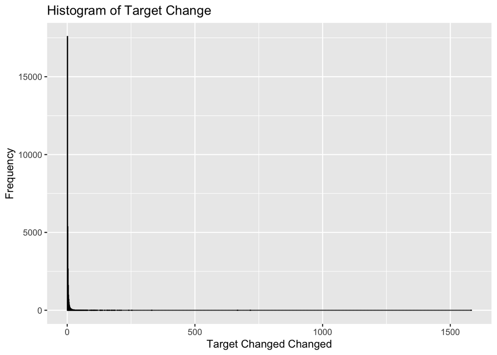

Excluding the numerous nominators that only ever did their first nomination, the following picture arises:

(Active Filters: only active Nominators, no 1kv Nominators, target changes > 1)

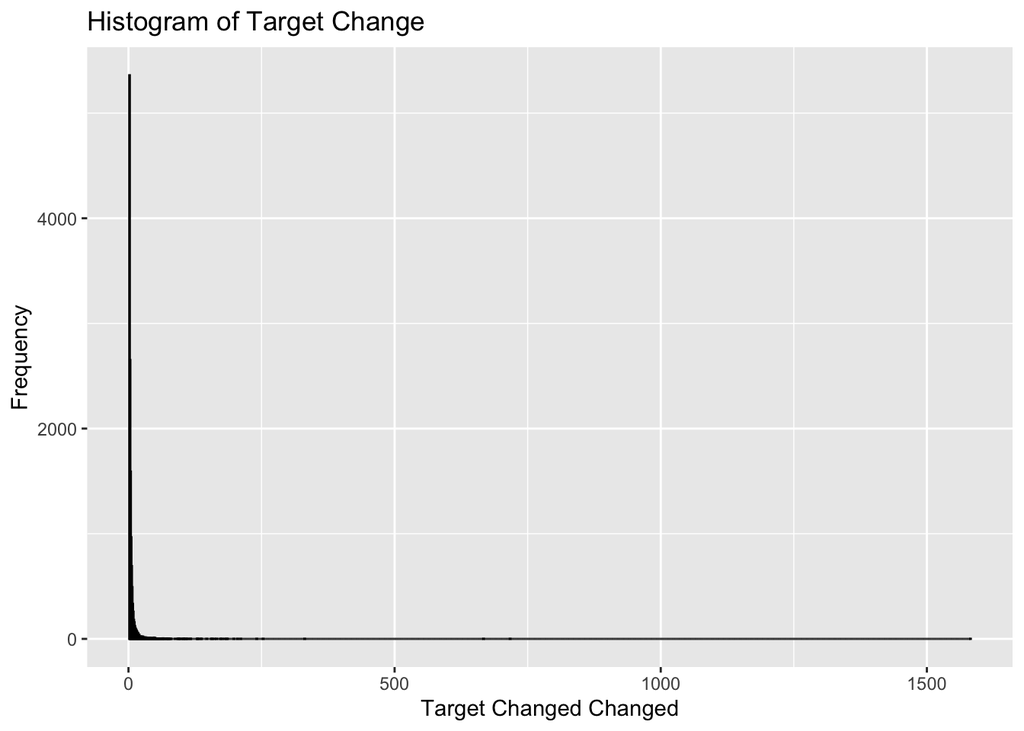

As an interesting additional analysis, we can look only at nomination pools and see how they behave.

(Active filters: only active Nominators, no 1kv Nominators, is_pool = TRUE)

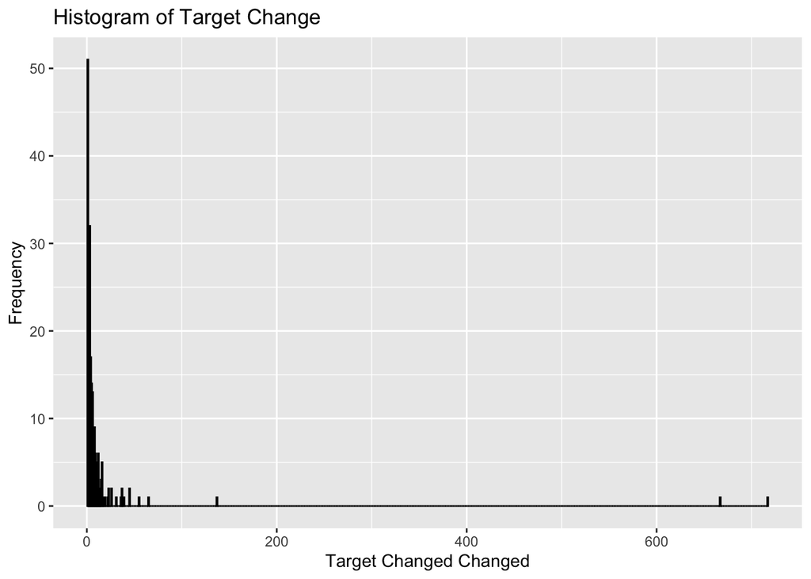

Nomination pools appear generally more active than the average nominator, but have still a surprisingly high average time since they last updated their nominations (340 days). This might be due to the fact that several pools are run by validators themselves and only include themselves into their selection.

To summarize the data, we can clearly say that nominators rarely engage with their nomination after their initial action to become a nominator. On average and after their initial activation, nominators only change their targets 2.07 times (1.99 if we exclude pools and 12.48 if we only look at pools). While there are some much more active nominators, this is a strong indication that a large share of nominators simply set and forget.

### Validators

In this section, we delve deeper into the composition of Validator backing. Our focus is on the number of days since the active Nominators of each Validator last changed their targets. Additionally, we adjust these days by the relative size of each Nominator’s bond in relation to the total bonded amount of the Validator. This metric, referred to as **Weighted Backing Age** (WBA), provides insight into how much of a Validator’s backing comes from earlier or newer nominations.

Consider the following example: Suppose a Validator has two Nominators, A and B. Nominator A has not updated their targets in 50 days and has a bonded amount of 5000 DOT. Nominator B, on the other hand, has not updated their targets in 1000 days and has a bonded amount of 20,000 DOT. Instead of simply averaging the backing age as (50 + 1000) / 2 = 525 days, we account for the fact that one Nominator contributes significantly more to the backing. Mathematically, this is calculated as: 5000 / (20000+5000) * 50 + 20000 / (20000+5000) * 1000 = 810. In this example, the WBA is larger than the simple average, because the Nominator contributing most to the backing is from longer ago. This, of course, also works the other way around.

The following graph plots the density of the WBA for all Validators in the active set.

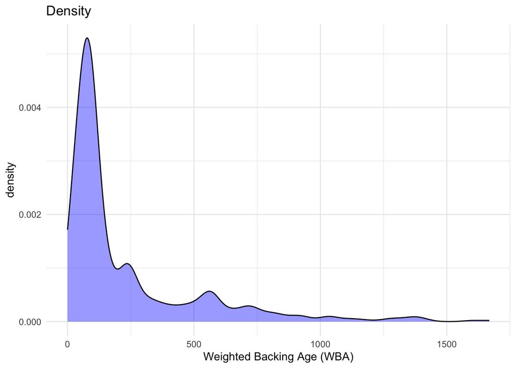

Given the data above, we can say, for example, that 30% of the density is above 180 days (or around 6 months). In other words, 30% of the total backing of all Validators is older than 6 months.

The following histogram provides additional information about the distribution of the staleness metric on a per-Validator basis of all active Validators (n = 600).

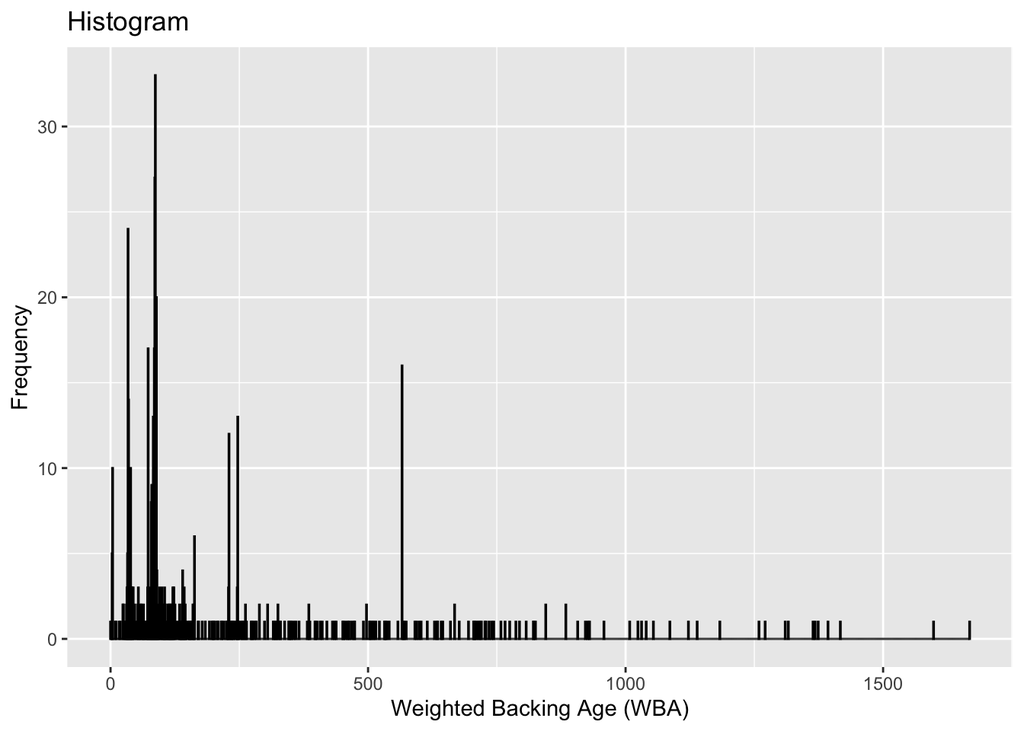

The following table sorts active Validators based on their weighted backing age and provides prints the highest 30 entries. Validators without a set identity are labelled “pseudo-a”.

Summary of Weighted Backing Age

| Stash Address | Validator Name | Weighted Backing Age |
| --- | --- | --- |
| 12GTt3pfM3SjTU6UL6dQ3SMgMSvdw94PnRoF6osU6hPvxbUZ | pseudo-a | 1668 |
| 12713bbq45c66CN9AD7yusSXWE1kY91DcMpjVcB2rXqZKy2w | 🔒stateless_money🔒 | 1598 |
| 15MUBwP6dyVw5CXF9PjSSv7SdXQuDSwjX86v1kBodCSWVR7c | General-Beck / Laniakea | 1417 |
| 1zugcabTuN7rs1bFYb33gRemtg67i4Mvp1twW85nQKiwhwQ | Zug Capital / 05 | 1393 |
| 1zugcaiwmKdWsfuubmCMBgKKMLSef2TEC3Gfvv5GxLGTKMN | Zug Capital / 09 | 1374 |
| 15qomv8YFTpHrbiJKicP4oXfxRDyG4XEHZH7jdfJScnw2xnV | P2P.ORG / 3 | 1368 |
| 1zugcacan4nrJ3HPBmiBgEn2XvRMbehqvmzSQXT3uLBDkh3 | Zug Capital / 10 | 1364 |
| 16GDRhRYxk42paoK6TfHAqWej8PdDDUwdDazjv4bAn4KGNeb | CP287-CLOUDWALK | 1316 |
| 14xKzzU1ZYDnzFj7FgdtDAYSMJNARjDc2gNw4XAFDgr4uXgp | Ryabina / 2 | 1310 |
| 14pU6dcr5jgMpFZDGB1fwcU6LztP5pszTk5mYz8nUXBu59mU | ZKV / 01 | 1271 |
| 15KJFabioS7ieTiNCkKkLpgZ5JUyPhTBF6y128R7Z6Rsx3kq | ZKV / 02 | 1259 |
| 16SpacegeUTft9v3ts27CEC3tJaxgvE4uZeCctThFH3Vb24p | Staker Space | 1183 |
| 15oKi7HoBQbwwdQc47k71q4sJJWnu5opn1pqoGx4NAEYZSHs | P2P.ORG / 5 | 1139 |
| 1zugcacYFxX3HveFpJVUShjfb3KyaomfVqMTFoxYuUWCdD8 | Zug Capital / 18 | 1122 |
| 1653t723BHhC2krGCFKUUNDQb5sUafy5pZvKVwnwo1oMAMi7 | Staked | 1086 |
| 14Y626iStBUWcNtnmH97163BBJJ2f7jc1piGMZwEQfK3t8zw | P2P.ORG / 17 | 1054 |
| 1zugcakrhr3ZR7q7B8WKuaZY5BjZAU43m79xEyhNQwLTFjb | Zug Capital / 22 | 1040 |
| 16DKyH4fggEXeGwCytqM19e9NFGkgR2neZPDJ5ta8BKpPbPK | P2P.ORG / 2 | 1031 |
| 14yx4vPAACZRhoDQm1dyvXD3QdRQyCRRCe5tj1zPomhhS29a | PureStake / 01 | 1024 |
| 14AkAFBzukRhAFh1wyko1ZoNWnUyq7bY1XbjeTeCHimCzPU1 | P2P.ORG / 12 | 1008 |
| 1RG5T6zGY4XovW75mTgpH6Bx7Y6uwwMmPToMCJSdMwdm4EW | IOSG Ventures | 958 |
| 13giQQe5CS4AAjkz1roun8NYUmZAQ2KYp32qTnJHLTcw4VxW | P2P.ORG / 9 | 930 |
| 11uMPbeaEDJhUxzU4ZfWW9VQEsryP9XqFcNRfPdYda6aFWJ | P2P.ORG / 4 | 927 |
| 1zugcaaABVRXtyepKmwNR4g5iH2NtTNVBz1McZ81p91uAm8 | Zug Capital / 02 | 922 |
| 15CosmEmAfQAhnxwan18e5TueAe6bDzrqqxg13dToDWr7A8M | COSMOON | 907 |
| 12ud6X3HTfWmV6rYZxiFo6f6QEDc1FF74k91vF76AmCDMT4j | P2P.ORG / 7 | 884 |
| 13BeUcLu7hzSTaoKpEtpdqiXKZz6yVfT9exKH6JuTW8RQQvJ | KeepNode / carbon | 884 |
| 15a9ScnYeVfQGL9HQtTn3nkUY1DTB8LzEX391yZvFRzJZ9V7 | Jaco / v04 | 845 |
| 15fU523Wq5BCt2NWAmrCU6p8nFB29uVifeG7bwYJHbw5Mmd9 | SNZPool-1 | 845 |
| 1RJP5i7zuyBLtgGTMCD9oF8zQMTQvfc4zpKNsVxfvTKdHmr | pos.dog / 7 | 825 |

The average WBA of all active Validators is 230 (and 224 for Validators without 100% commission).

**Note:** As mentioned above, the table above is purely descriptive and it does not necessarily mean that a large WBA is a bad thing. Validators that have a large WBA, by definition, also are long-time contributors to the Polkadot Network.

# Conclusion

The analysis presented here has shown that many if not most Nominators never really engage with their nominations (at least through on-chain activity) again. On average, nominators only change their Validator selection 2.07 times and the average time since the last change is 648 days. This directly translates into the average **Weighted Backing Age** of Validators which amounts to 230. In other words, not only do most nominators not frequently update or change their selection of validators, they also hold a significant share of the total stake in the system.